# heart_disease_Prediction

**Table of Contents**

1. **Motivation**
2. **Imported Libraries**
   1. Processing
   2. Modeling
   3. Visualization
3. **Dataset Overview**
   1. Header Explanation
   2. Presence vs Absence
4. **Exploratory Data Analysis**
   1. Understanding Feature Relationships
   2. Principal Component Analysis
5. **Data-driven Model**
   1. Feature Selection
   2. Train-Test Split
   3. Model Selection and Evaluation
      - Assessing Models
      - Comparison Models
6. **Conclusion**

# Motivation

Heart disease stands as a significant and prevalent global health concern, impacting millions across the world. Its grave consequences make it the foremost cause of death not only in developed nations but also in numerous developing regions. With its spectrum of symptoms and complications, encompassing factors like chest pain and others documented within our dataset, addressing heart disease promptly and effectively becomes paramount. The pivotal goals we set out to achieve involve the early prediction, diagnosis, and subsequent treatment of heart disease. Through this endeavor, we aim to empower healthcare practitioners and systems with the ability to foresee the presence of heart disease in patients. This project holds a special place in the realm of data science, holding a distinguished status within the [Kaggle](https://www.kaggle.com/datasets/rishidamarla/heart-disease-prediction) community as a renowned endeavor.

# Imported Libraries

The following cells are used to bring in external Python libraries or modules that we need to use in this notebook. By leveraging Python packages like the following listed packages analysts can efficiently conduct data overviews and embark on a comprehensive data analysis journey to extract valuable knowledge from complex datasets.

## Processing

PCA (e.g. Data reduction: selecting, aggregating, or summarizing the data to reduce its size or complexity.) and preprocessing (e.g. Data normalization: scaling or standardizing the data to make it comparable or compatible across different features or samples.) are both related to the data preparation phase of data science, which is the process of transforming raw data into a format that can be used for analysis, modeling.  
[pandas:](https://pandas.pydata.org/) This is a Python package that provides fast and easy-to-use data structures and analysis tools, such as DataFrame and Series.  
[scikit-learn:](https://scikit-learn.org/stable/index.html) This is another Python package that provides various tools for data analysis (e.g. exploratory data analyses (EDA)) but also machine learning (see the next section), including [PCA](https://scikit-learn.org/stable/modules/generated/sklearn.decomposition.PCA.html) and other preprocessing methods.

```python
import pandas as pd
from sklearn.preprocessing import StandardScaler
from sklearn.decomposition import PCA
import numpy as np
from collections import Counter
import random
import re
import string
```

## Modeling

The modeling phase involves creating, training, and evaluating a machine learning model using the data that has been collected, annotated, and wrangled in the previous phases. There are many different types of classification models, such as logistic regression, decision trees, support vector machines, [neural networks](https://www.kaggle.com/code/ryanholbrook/a-single-neuron), and so on.  
scikit-learn: as in the last section mentioned it is also a Python package that provides various tools for machine learning and, such as classification, regression, clustering, feature selection, model evaluation, and model hyper-parameter optimization. Scikit-learn is also built on top of NumPy and [Scipy](https://scipy.org/) (They are actually used for both processing and modeling in data science.), and it follows a consistent and simple interface for creating and using machine learning models.  
[Keras:](https://keras.io/) is a popular Python package that provides a high-level API for creating and using deep learning models. Deep learning is a branch of machine learning that uses multiple layers of artificial neural networks to learn from complex and high-dimensional data. Keras can work with different backends, such as [TensorFlow](https://www.tensorflow.org/api_docs/python/tf/) or Theano, which are frameworks that offer low-level operations for building and running deep learning models. Keras can help with data representation, data learning, and data generation.

```python
from scipy import interp # This can be replaced newly by 'interp' from numpy.
from tqdm import tqdm
from sklearn.model_selection import StratifiedKFold
from sklearn.linear_model import LogisticRegression
from sklearn.ensemble import GradientBoostingClassifier
from sklearn.discriminant_analysis import LinearDiscriminantAnalysis
from sklearn.neighbors import KNeighborsClassifier
from sklearn.svm import SVC
from sklearn import tree
from sklearn.tree import DecisionTreeClassifier
from sklearn.ensemble import RandomForestClassifier
from sklearn import metrics
from sklearn.metrics import classification_report
from sklearn.metrics import confusion_matrix
from sklearn.metrics import roc_auc_score
from sklearn.metrics import roc_curve, auc

import tensorflow as tf
from tensorflow import keras
from keras.models import Sequential
from keras.layers import Dense
from keras.optimizers import SGD
from keras.utils import to_categorical
```

## Visualization

Data visualization is an important aspect of data analysis, as it can help to reveal patterns, trends, outliers, and relationships that might not be obvious from numerical or textual data alone. There are many tools and libraries available in Python for creating different types of plots, such as [matplotlib](https://matplotlib.org/) , [seaborn](https://seaborn.pydata.org/) (It is a visualization library based on matplotlib), and [plotly](https://plotly.com/python/plotly-fundamentals/) (express).

```python
# Import all necessary packages
from pathlib import Path
import plotly.express as px
import matplotlib.pyplot as plt
import seaborn as sbn
import seaborn.objects as so

sbn.set_style('whitegrid')
sbn.set(font_scale=1.0, font='sans-serif')
#import seaborn_image as isns
%matplotlib inline
plt.rcParams["figure.figsize"] = [8, 6]
font = {'family': 'serif',
        'color': 'darkblue',
        'weight': 'normal',
        'size': 18,
        }
kwargs = {'edgecolor': "black",  # for edge color
          'linewidth': 2,  # line width of spot
          }
from IPython.display import Markdown,display
from termcolor import colored
#import ast
```

# Dataset Overview

A thorough data overview is the cornerstone of any successful data analysis endeavor. It empowers analysts to identify data-related challenges, understand the dataset's characteristics, and uncover critical patterns and insights.

```python
df_heart_disease = pd.read_csv('../DS/datasets/heart_disease.csv', sep=',', encoding='utf-8-sig')
print(colored('The Head of Dataset:', attrs=['bold'], color='green'))
display(df_heart_disease.head(3))

print(colored('The Tail of Dataset:', attrs=['bold'], color='red'))
display( df_heart_disease.tail(3))

print(colored('The Dataset (short) Overview:', attrs=['bold'], color='blue'))
display(df_heart_disease.info())
df_test = df_heart_disease.head()
```

```
The Head of Dataset:
```

|  | age | sex | cp | trestbps | chol | fbs | restecg | thalach | exang | oldpeak | slope | ca | thal | target |
| --- | --- | --- | --- | --- | --- | --- | --- | --- | --- | --- | --- | --- | --- | --- |
| 0 | 63 | 1 | 3 | 145 | 233 | 1 | 0 | 150 | 0 | 2.3 | 0 | 0 | 1 | 1 |
| 1 | 37 | 1 | 2 | 130 | 250 | 0 | 1 | 187 | 0 | 3.5 | 0 | 0 | 2 | 1 |
| 2 | 41 | 0 | 1 | 130 | 204 | 0 | 0 | 172 | 0 | 1.4 | 2 | 0 | 2 | 1 |

```
The Tail of Dataset:
```

|  | age | sex | cp | trestbps | chol | fbs | restecg | thalach | exang | oldpeak | slope | ca | thal | target |
| --- | --- | --- | --- | --- | --- | --- | --- | --- | --- | --- | --- | --- | --- | --- |
| 300 | 68 | 1 | 0 | 144 | 193 | 1 | 1 | 141 | 0 | 3.4 | 1 | 2 | 3 | 0 |
| 301 | 57 | 1 | 0 | 130 | 131 | 0 | 1 | 115 | 1 | 1.2 | 1 | 1 | 3 | 0 |
| 302 | 57 | 0 | 1 | 130 | 236 | 0 | 0 | 174 | 0 | 0.0 | 1 | 1 | 2 | 0 |

```
The Dataset (short) Overview:
<class 'pandas.core.frame.DataFrame'>
RangeIndex: 303 entries, 0 to 302
Data columns (total 14 columns):
 #   Column    Non-Null Count  Dtype
---  ------    --------------  -----
 0   age       303 non-null    int64
 1   sex       303 non-null    int64
 2   cp        303 non-null    int64
 3   trestbps  303 non-null    int64
 4   chol      303 non-null    int64
 5   fbs       303 non-null    int64
 6   restecg   303 non-null    int64
 7   thalach   303 non-null    int64
 8   exang     303 non-null    int64
 9   oldpeak   303 non-null    float64
 10  slope     303 non-null    int64
 11  ca        303 non-null    int64
 12  thal      303 non-null    int64
 13  target    303 non-null    int64
dtypes: float64(1), int64(13)
memory usage: 33.3 KB
```

```
None
```

## Presence vs Absence

This section refers to the comparison of the two possible outcomes, as shortly mentioned in the last section. The target variable is a crucial focus of analysis to understand the presence or absence of heart disease in the patients being studied.

|  | target | counts |
| --- | --- | --- |
| 0 | Present | 165 |
| 1 | Absent | 138 |

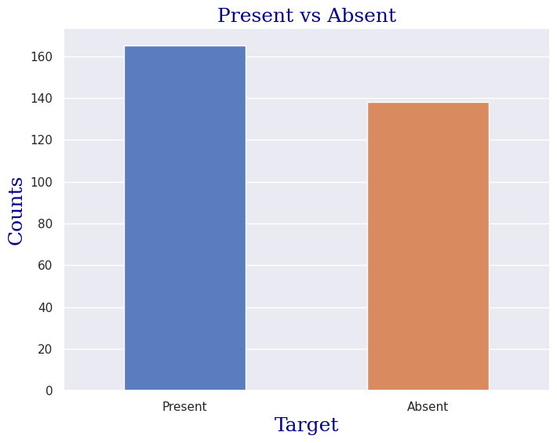

```python
"""
Comparison between patients with heart disease and without that according their age
present:  with heart disease
absent:  without heart disease
"""
# Firstly, we condense the dataframe so it counts the number of times each target appears
present_absent = df_heart_disease['target'].value_counts().rename_axis('target').to_frame('counts').reset_index()
present_absent['target'] = present_absent['target'].replace({1:'Present', 0:'Absent'})
display(present_absent)

# Plot a bar chart of the counts
fg1 = sbn.barplot(data= present_absent, x='target', y='counts', palette='muted', width=0.5)
fg1.set_title('Present vs Absent', fontdict=font)
fg1.set_xlabel('Target', fontdict=font)
fg1.set_ylabel('Counts', fontdict=font)
```

Next, it would be useful for us to gain some insight into whether the chest pain (cp) of the patient plays an important role in the presence or absence of heart disease.

|  | target | cp | counts |
| --- | --- | --- | --- |
| 0 | Absent | 0 | 104 |
| 1 | Present | 2 | 69 |
| 2 | Present | 1 | 41 |
| 3 | Present | 0 | 39 |
| 4 | Absent | 2 | 18 |
| 5 | Present | 3 | 16 |
| 6 | Absent | 1 | 9 |
| 7 | Absent | 3 | 7 |

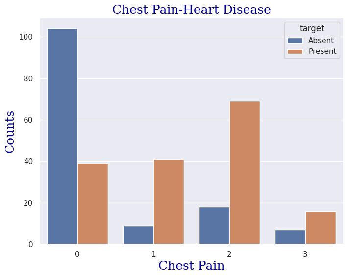

```python
present_absent_cp = df_heart_disease[['target', 'cp']].value_counts().to_frame('counts').reset_index()
present_absent_cp['target'] = present_absent_cp['target'].replace({1:'Present', 0:'Absent'})
display(present_absent_cp)
#present_absent_age.plot()
fg2 = sbn.barplot(data=present_absent_cp, x='cp', y='counts',hue='target')
fg2.set_title('Chest Pain-Heart Disease', fontdict=font)
fg2.set_xlabel('Chest Pain', fontdict=font)
fg2.set_ylabel('Counts', fontdict=font)
```

|  | target | age | counts |
| --- | --- | --- | --- |
| 0 | Absent | 58 | 12 |
| 1 | Absent | 57 | 10 |
| 2 | Present | 54 | 10 |
| 3 | Absent | 59 | 9 |
| 4 | Present | 52 | 9 |
| ... | ... | ... | ... |
| 70 | Absent | 69 | 1 |
| 71 | Absent | 77 | 1 |
| 72 | Present | 29 | 1 |
| 73 | Absent | 38 | 1 |
| 74 | Present | 76 | 1 |

75 rows × 3 columns

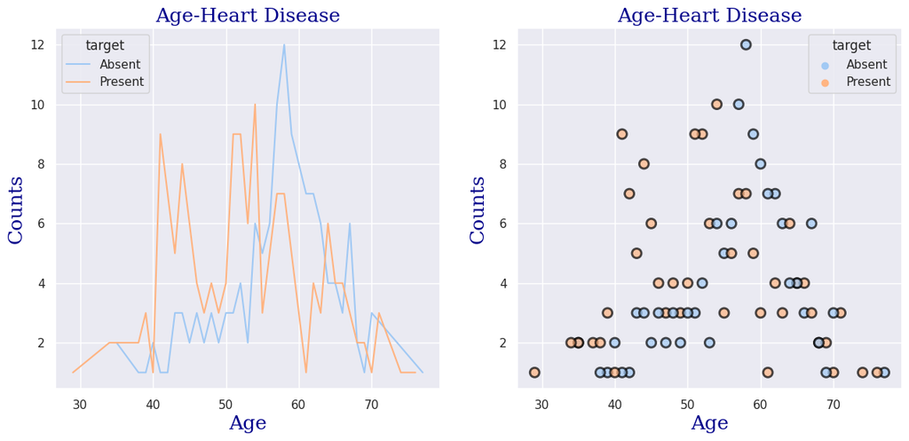

```python
present_absent_age = df_heart_disease[['target', 'age']].value_counts().to_frame('counts').reset_index()
present_absent_age['target'] = present_absent_age['target'].replace({1:'Present', 0:'Absent'})
display(present_absent_age)
#present_absent_age.plot()
ax1= plt.subplots(nrows=1, ncols=2, figsize=(14,6))[1]
fg3 = sbn.lineplot(data=present_absent_age, x='age', y='counts', hue='target',ax=ax1[0], palette='pastel')
sbn.move_legend(ax1[0], 'upper left')
ax1[0].set_title('Age-Heart Disease', fontdict=font)
ax1[0].set_xlabel('Age', fontdict=font)
ax1[0].set_ylabel('Counts', fontdict=font)

fg4= sbn.scatterplot(data=present_absent_age, x='age', y='counts', ax=ax1[1], hue= 'target', palette='pastel',
 s=75, alpha=0.7,**kwargs)
ax1[1].set_title('Age-Heart Disease', fontdict=font)
ax1[1].set_xlabel('Age', fontdict=font)
ax1[1].set_ylabel('Counts', fontdict=font)
```

# Exploratory Data Analysis

The last section demonstrated that observing an individual feature (in this case, the age of the patients) alone does not provide clear or conclusive information to accurately predict the presence or absence of heart diseases in the patients.  
The reason for this limitation is that the presence or absence of heart diseases is influenced by multiple factors ([Multivariate Analysis (MVA)](https://en.wikipedia.org/wiki/Multivariate_statistics#Multivariate_analysis), and a single feature, such as age, might not capture the full complexity of the relationship. To overcome this limitation and improve prediction accuracies, it is necessary to proceed with further steps, as we explain can in the two next sections.

## Understanding Feature Relationships

To achieve this, we will in the next steps visualize the features regarding their correlations.

First we split the dataset into the feature Matrix **X** and the target array as corresponding class labels **y**.  
After that the feature matrix will be standardized by StandardScaler (from scikit-learn ) with scales the features to have zero mean and unit variance.

```python
X = df_heart_disease.iloc[:,0:13].values
y = df_heart_disease.iloc[:,13].values

X_sts = StandardScaler().fit_transform(X)
```

Data normalization is a preprocessing technique that scales the data to a standardized range. By normalizing the data, we ensure that all features have the same scale, which is particularly useful when dealing with features that have different units or ranges. This can improve the performance of certain machine learning algorithms that are sensitive to the scale of the features.

```python
df_norm = pd.DataFrame(X_sts, index=df_heart_disease.index, columns=df_heart_disease.columns[0:13])

# Insert a non-feature target column to the dataframe
df_norm['target'] = df_heart_disease['target']
df_norm.head(10)

X = df_norm.iloc[:,0:13].values
y = df_norm.iloc[:,13].values
```

We calculate the correlation matrix for a normalized DataFrame and then create a heatmap to visually represent the correlations between its columns. The heatmap displays the correlation values between different features (columns) of the DataFrame, with the x-axis and y-axis labeled using the column names of the DataFrame.

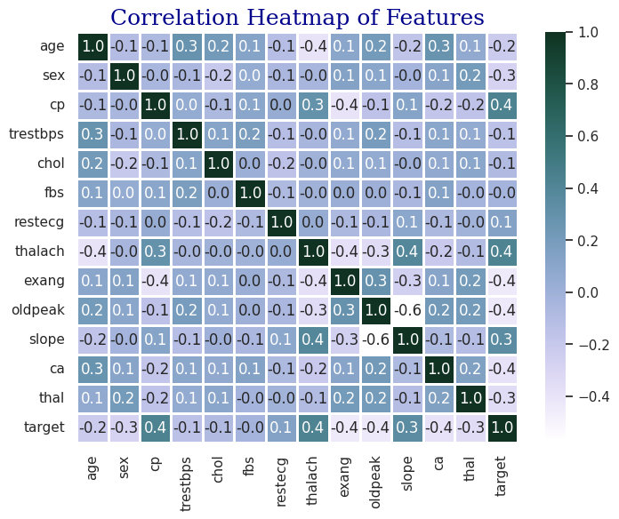

```python
corr = df_norm.corr()
fg5 = sbn.heatmap(data=corr,xticklabels=corr.columns, yticklabels=corr.columns, linewidths=.75,
 annot=True, fmt='.1f', cmap=sbn.cubehelix_palette(as_cmap=True, start=2, light=1))
fg5.set_title('Correlation Heatmap of Features', fontdict=font)
```

## Principal Component Analysis

PCA is employed as a preprocessing step to simplify the data and facilitate its exploration and visualization. It helps identify strong patterns and relationships in the data, which can aid in understanding the underlying structure and informing subsequent analyses or modeling tasks.

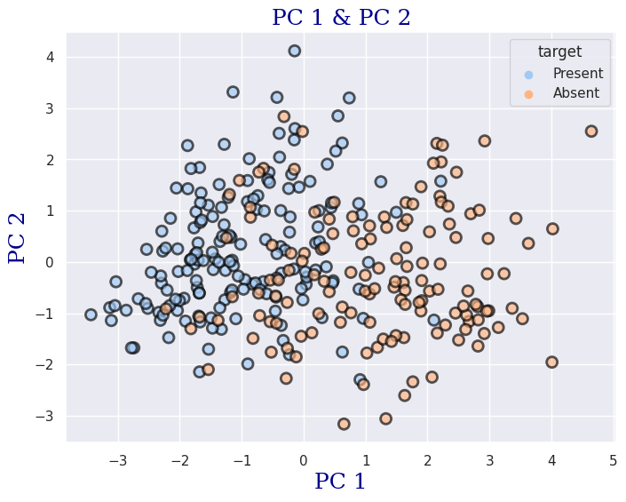

```python
pca = PCA(n_components=2)
pcs = pca.fit_transform(X)
df_pc = pd.DataFrame(data = pcs, columns = ['PC 1', 'PC 2'])
#dff:dtat frame final
dff = pd.concat([df_pc, df_heart_disease[['target']]], axis = 1)
dff['target'] = dff['target'].replace({1:'Present', 0:'Absent'})
x_tar = dff[df_heart_disease['target'] == 'Present']
y_tar = dff[dff['target'] == 'Absent']
fg6 = sbn.scatterplot(data=dff, x='PC 1', y='PC 2', hue='target', palette='pastel',
        s=75, alpha=0.65,**kwargs)
fg6.set_title('PC 1 & PC 2', fontdict=font)
fg6.set_xlabel('PC 1', fontdict=font)
fg6.set_ylabel('PC 2', fontdict=font)
```

# Data-driven Model

Data-driven Model consists of many computational methods that can be divided into two main categories: [clustering](https://en.wikipedia.org/wiki/Cluster_analysis) and classification. The emphasis is here on using data-driven approaches to develop a classification model that accurately predicts the class labels of new data based on its features and finally validated the classification. The process of data-driven classification typically includes many steps as listed in the next sections.

### **Data Preprocessing:**

This step basically involves cleaning, transforming, and preparing the dataset for modeling. It includes handling missing values, encoding categorical variables, and scaling numerical features if necessary.  
Notice: This has happen already during the last section.

## Feature Selection

Selecting relevant features or extracting important information from the data to be used as inputs for the classification model. This step aims to reduce dimensionality and focus on the most informative features. In the following, we choose the Sequential Feature Selector (**SFS**) class with the setting defined in the sfs_config dictionary. This dictionary contains specific configurations to customize the behavior of the SFS:

- forward: indicates if the Sequential Feature Selector will perform a forward feature selection process. In forward feature selection, the process starts with an empty set of features and iteratively adds one feature at a time that improves the model's performance the most. This continues until a stopping criterion is met.
- floating: combines forward feature and backward selection (it is the inverse of forward feature selection start with all features and iteratively removes one feature at a time that has the least impact on the model's performance) which is basically more expensive than individual forward or backward selection, but it offers the advantage of exploring a wider range of feature combinations, potentially leading to better feature subsets for improved model performance.
- scoring: This sets the scoring parameter to 'accuracies', indicating that the accuracies metric will be used to evaluate the quality of selected feature subsets.
- cv: This sets the cv parameter to 5, specifying that 5-fold cross-validation will be used during the feature selection process. This means that the dataset will be divided into 5 subsets (folds), and the feature selection algorithm will run 5 times. In each run, one of the subsets will be used as the test set, and the other four subsets will be used as the training set. The purpose of cross-validation is to provide a more robust estimate of the model's performance by evaluating it on different subsets of the data.

Using a [pipeline](https://scikit-learn.org/stable/modules/generated/sklearn.pipeline.make_pipeline.html) that integrates SFS provides a structured and controlled environment for feature selection, ensuring that it's performed in a consistent and reliable manner across different stages of the modeling process. It also supports proper evaluation techniques like cross-validation and facilitates easier experimentation and customization.

```python
from mlxtend.feature_selection import SequentialFeatureSelector as SFS

# To avoid the repetition of som settings of the SFS
sfs_config = {
    'forward': True,
    'floating': False,
    'scoring': 'accuracies',
    'cv': 5
}
```

## Train-Test Split

Splitting the dataset into training and testing subsets. The training set is used to train the classification model, while the testing set is used to evaluate its performance on unseen data. The splitting below separates the feature matrix **X** (containing input features) from the target array **y** (containing class labels). The data is split into training and testing sets, with 70% of the data used for training and 30% for testing as shortly mentioned above. Setting the random_state parameter ensures that the train and test sets will be the same every time you run the code, which can be useful for reproducibility. This process is a crucial step in data preparation for building and evaluating predictive models in machine learning tasks in later steps.

```python
from sklearn.model_selection import train_test_split
X_train, X_test, y_train, y_test = train_test_split(X, y, test_size=0.3, random_state=0)
```

## Model Selection and Evaluation

```python
from sklearn.model_selection import train_test_split
from mlxtend.feature_selection import SequentialFeatureSelector as SFS
from tqdm import tqdm
from sklearn import model_selection
from sklearn.pipeline import make_pipeline
from sklearn.metrics import classification_report
from sklearn.metrics import roc_curve, auc


class ModelEvaluator:
    results = {'acc_test': {}, 'acc_train': {}, }
    #--------------------------------------------------------------------
    # Constructor
    #--------------------------------------------------------------------
    def __init__(self, model=LinearDiscriminantAnalysis(), df=df_heart_disease, n=13, cvn=5, mif=1, maf=5, head='target'):

        # Check the number of the features of dataframe greater than cross validation number.
        if df.shape[1] < n:
            raise InvalidDataError('Number of features of dataframe is less than the target index number')

        # Check the maximum number of the feature range of a SFS greater than its minimum number.
        elif maf < mif:
            raise InvalidDataError('Maximum number of feature range of a SFS is less than the minimum number')

        # Check the maximum number of the feature range less than or equal cross validation number.
        elif maf > cvn:
            raise InvalidDataError('Maximum number of feature range of a SFS is greater than the the cross-validation number')
        else:
            X_ = df.iloc[:,0:n].values
            y_ = df.iloc[:,n].values
            df_norm = pd.DataFrame(X_sts, index=df.index, columns=df.columns[0:13])
            df_norm[head] = df_heart_disease[head]
            df_norm.head(10)

            self.X = df_norm.iloc[:,0:13].values
            self.y = df_norm.iloc[:,13].values
            self.X_train, self.X_test, self.y_train, self.y_test = train_test_split(
                            self.X, self.y, test_size=0.3, random_state=0)
            self.sfs = SFS(estimator=model, k_features=(mif, maf), forward=True,
            floating=False, scoring='accuracy', cv=cvn).fit(self.X, self.y)
            self.df = df
            self.model = model

    #---------------------------------------------------------------------
    # This function aims to find the optimal number of neighbors for a
    # K-Nearest Neighbors classifier using cross-validation. It takes
    # training data X_train and corresponding labels y_train as inputs.
    # It iterates over a range of potential neighbor counts, constructs
    # KNN models for each count, evaluates them using cross-validation,
    # and stores the mean accuracy scores. Finally, it determines the neighbor
    # count with the highest accuracy and prints the result. The optimal number
    # of neighbors is returned as the output of the function.
    #---------------------------------------------------------------------
    def k_opt(self, X_train = None, y_train=None):
        if X_train is None:
            X_train = self.X_train
        if y_train is None:
            y_train = self.y_train
        Ns = [N for N in list(range(1,50)) if N % 2 == 1]
        cv_scores = []

        for k in Ns:
            knn = KNeighborsClassifier(n_neighbors = k + 1, weights='uniform', p=2, metric='euclidean')
            kf = model_selection.KFold(n_splits=10, shuffle=True, random_state=123)
            scores = model_selection.cross_val_score(knn, X_train, y_train, cv=kf, scoring='accuracy')
            cv_scores.append(scores.mean()*100)
            #print("k=%d %0.2f (+/- %0.2f)" % (k_value, scores.mean()*100, scores.std()*100))

        #opt_k = Ns[cv_scores.index(max(cv_scores))]
        opt_k = Ns[np.argmax(cv_scores)]
        #print ()
        print(( 'The optimal number of neighbors is %d with avg_acc of KNN %0.1f%%.' % (opt_k, cv_scores[Ns.index(opt_k)])))
        return opt_k

    #-------------------------------------------------------------------------
    # This This method encapsulates the process of building, training, evaluating,
    # and plotting the results of a neural network model for a given dataset.
    # The flexibility in specifying different parameters allows you to experiment
    # with different network architectures and training settings. The boolean input
    #'_tqdm' determines whether the model is trained using Keras' built-in progress
    #  bar (when _tqdm is set to False) or using a loop over the epoch number with
    #  a tqdm progress bar (when _tqdm is set to True).
    #-------------------------------------------------------------------------
    def nnw(self, hu1=64, hu2=32, lr=0.001, num_epoch=1000, _tqdm=True, X_train=None,
     y_train=None, X_test=None, y_test=None):
        if X_train is None:
            X_train = self.X_train
        if y_train is None:
            y_train = self.y_train
        if X_test is None:
            X_test = self.X_test
        if y_test is None:
            y_test = self.y_test

        # Build model
        model = Sequential()
        model.add(Dense(hu1, input_dim=13, activation='relu'))
        model.add(Dense(hu2, activation='relu'))
        model.add(Dense(2, activation='softmax'))
        # Choose optimizer and loss function
        optimizer = SGD(learning_rate=lr, momentum=0.7)
        model.compile(loss='categorical_crossentropy', optimizer=optimizer, metrics=['accuracy'])

        # Convert labels to one-hot encoding
        yTrain_oneHot = to_categorical(y_train, num_classes=2)
        if _tqdm:
            # Train the model with tqdm progress bar
            progress_bar = tqdm(range(num_epoch), unit="epoch")
            loss_per_epoch = []  # Store loss values for each epoch
            for epoch in progress_bar:
                history = model.fit(X_train, yTrain_oneHot, epochs=1, verbose=0)
                loss_per_epoch.append(history.history['loss'][0])  # Append the loss for this epoch
        else:
            # Train the model with built-in progress bar
            history = model.fit(X_train, yTrain_oneHot, epochs=num_epoch, verbose=1)
            loss_per_epoch = history.history['loss']
        # Plot the training loss
        epochs = np.arange(1, num_epoch + 1)
        fg10 = sbn.lineplot(x= epochs, y=loss_per_epoch, label='Training', legend=True)
        fg10.set_ylabel('Average Loss', fontdict=font)
        fg10.set_xlabel('Epochs', fontdict=font)
        fg10.set_title('Heart Disease', fontdict=font)
        fg10.legend()
```

```python
        # Evaluate the model on test data
        yTest_oneHot = to_categorical(y_test, num_classes=2)
        accuracies_test = model.evaluate(X_test, yTest_oneHot, verbose=0)[1]

        # Evaluate the model on training data
        accuracies_train = model.evaluate(X_train, yTrain_oneHot, verbose=0)[1]

        print('Accuracies of the network on test data: {:.2f}%'.format(accuracies_test * 100))
        print('Accuracies of the network on training data: {:.2f}%'.format(accuracies_train * 100))


    #-------------------------------------------------------------------
    # The function valuates the model's accuracy on both the training
    # and test sets, and it allows for easy tracking and comparison of
    # different models by storing their accuracy scores in dictionaries.
    #-------------------------------------------------------------------
    def accuracies(self, model= None, display=True,
     X_train=None,X_test=None, y_train=None, y_test=None):

        if model is None:
            model = self.model
        if X_train is None:
            X_train = self.X_train
        if X_test is None:
            X_test = self.X_test
        if y_train is None:
            y_train = self.y_train
        if y_test is None:
            y_test = self.y_test

        model.fit(self.X_train, self.y_train)
        y_pred = model.predict(X_test)
        # Update results dictionaries
        acc_train = round(model.score(self.X_train, y_train) * 100, 2)
        acc_val = round(model.score(self.X_test, y_test) * 100, 2)
        if 'Pipeline' in str(model):
            method_name = str(model.steps[-1][1])[0:str(model.steps[-1][1]).find('(')]
            method_name += '_pip'
        else:
            method_name = str(model)[0:str(model).find('(')]

        self.results['acc_test'][method_name] = acc_val
        self.results['acc_train'][method_name] = acc_train

        method_data = {method_name:{'y_pred': [y_pred], 'acc_val':acc_val, 'acc_train': acc_train}}

        if display:
            print('acc_train: %.2f\n'
                'acc_val: %.2f' %(acc_train, acc_val))
        else:
            return method_data

    #-------------------------------------------------------------------
    # This function encapsulates the steps needed to create and train a
    # pipeline,making it convenient work with models that involve feature
    # selection.
    #------------------------------------------------------------------
    def getPipe(self):
        pipe = make_pipeline(
            self.sfs,
            StandardScaler(),
            self.model
        )
        pipe = pipe.fit(self.X, self.y)
        return pipe

    #-------------------------------------------------------------------
    # The following function serves as a utility to print and retrieve
    # the names and indices of the selected features obtained from the
    # Sequential Feature Selector object.
    #-------------------------------------------------------------------
    def display_features(self, sfs=None):
        if sfs is None:
            sfs = self.sfs
        #if display == 0:
            # Assuming sfs is an instance of the SequentialFeatureSelector class
        feature_names_dict = {sfs.k_feature_idx_[i]: self.df.iloc[:, sfs.k_feature_idx_[i]].name
                        for i in range(len(sfs.k_feature_idx_))}
        print('Selected features: ',  feature_names_dict)
        print('\n')
        return tuple(np.array(sfs.k_feature_idx_[0:]))

    #------------------------------------------------------------------------
    # This function provides a quick and easy way to assess the performance of
    # a classification model and is useful for evaluating its effectiveness
    # in distinguishing between different classes.
    #------------------------------------------------------------------------
    def class_report(self):
        report = classification_report(y_true=self.y_test,
        y_pred=self.getPipe().predict(self.X_test), output_dict=True)
        df_report = pd.DataFrame(report).transpose()
        return df_report

    #------------------------------------------------------------------
    # The val_diags function provides a comprehensive analysis of the
    # classification model's performance using cross-validated ROC curves,
    #  which helps assess the model's ability to distinguish between
    # classes and compare its performance across different folds.
    # Additionally it plots histogram of the mean TPR and TNR values.
    #------------------------------------------------------------------
    def val_diags(self, model=None, X=None, y=None, cvn=5):
        cv = StratifiedKFold(n_splits=cvn)
        # List to store TPR, TNR, and AUC values
        tprs = []
        tnrs = []
        aucs = []

        ax2 = plt.subplots(nrows=1, ncols=2, figsize=(14, 6))[1]
        _fprs = np.linspace(start=0, stop=1, num=300)

        if model is None:
            model = self.getPipe()
        if X is None:
            X = self.X
        if y is None:
            y = self.y
        attrs = self.display_features()

        for i, (train, test) in enumerate(cv.split(X=X[:, attrs], y=y)):
            predicts = model.fit(X[train], y[train].ravel()).predict_proba(X[test])
            fpr, tpr = roc_curve(y[test].ravel(), predicts[:, 1])[0:2]

            tprs.append(np.interp(_fprs, fpr, tpr))
            #fprs.append(fpr)

            # Calculate TNR based on TPR and FPR
            tnr = 1 - fpr
            tnrs.append(np.interp(_fprs, fpr, tnr))  # Interpolate TNR values

            tprs[-1][0] = 0.0

            roc_auc = auc(fpr, tpr)
            aucs.append(roc_auc)
            fg7 = sbn.lineplot(data=pd.DataFrame({'fpr': fpr, 'tpr': tpr}), x='fpr', y='tpr', alpha=0.3, legend='full',
                            label='ROC fold %d (AUC = %0.2f)' % (i, roc_auc), err_style='band', ax=ax2[0])

        fg7 = sbn.lineplot(x=[0, 1], y=[0, 1], label='Diagonal', legend='full', lw=1.5, alpha=0.7, ax=ax2[0])
```

```python
        mean_tpr = np.mean(tprs, axis=0)
        mean_tpr[-1] = 1.0
        mean_auc = auc(_fprs, mean_tpr)
        std_auc = np.std(aucs)
        fg7 = sbn.lineplot(x=_fprs, y=mean_tpr, label=r'Mean ROC (AUC = %0.2f $\pm$ %0.2f)'
                        % (mean_auc, std_auc), lw=2.2, alpha=.7, err_style='band', ax=ax2[0])

        # Calculate and plot Mean TNR (Specificity)
        mean_tnr = np.mean(tnrs, axis=0)
        mean_tnr[-1] = 1.0  # Set the last TNR value to 1.0 for proper plotting
        #fg7 = sbn.lineplot(x=_fprs, y=mean_tnr, label='Mean TNR (Specificity)', lw=2.2, alpha=.7, err_style='band', ax=ax2[0])

        fg7.set_title('ROC', fontdict=font)
        fg7.set_xlabel('FPR', fontdict=font)
        fg7.set_ylabel('TRR', fontdict=font)

        fg81= sbn.histplot(mean_tpr, label='TPR',ax=ax2[1], kde=True, legend=True, cbar=True, thresh=0, stat='frequency')
        fg81.legend()
        fg82= sbn.histplot(mean_tnr, label='TNR',ax=ax2[1], kde=True,legend=True, cbar=True, thresh=0, stat='frequency')
        fg82.legend()
        fg82.set_ylabel('Frequency',fontdict= font)

        #fg81= sbn.lineplot(x=_fprs,y=mean_tnr, label='TP',ax=ax2[1],  legend=True)


    #--------------------------------------------------------------------------------
    # The cfm(abbreviation of Confusion Matrix) function provides an easy-to-interpret
    # visualization of the classification model's performance in terms of true positive,
    # true negative, false positive, and false negative predictions, allowing for quick
    # assessment of the model's effectiveness in distinguishing between classes.
    #--------------------------------------------------------------------------------
    def cfm(self, model=None, X_test=None, y_test=None):
        if model is None:
            model = self.getPipe()

        if X_test is None:
            X_test = self.X_test

        if y_test is None:
            y_test = self.y_test

        y_pred = model.predict(X_test)
        cm = metrics.confusion_matrix(y_pred= y_pred, y_true= y_test, labels=[1, 0])
        fg9 = sbn.heatmap(cm, xticklabels=["1", "0"], yticklabels=["1", "0"], annot=True, fmt='.2f',
          cmap=sbn.cubehelix_palette(as_cmap=True, start=2, light=.75, dark=.25, gamma=.5,rot=-.2), linewidths=.75)
        #model_name = str(model.steps[-1][1])
        model_name = str(self.model)
        model_name = model_name[0:str(model_name).find('(')]
        fg9.set_title(model_name, fontdict=font)
        fg9.set_xlabel('Predicted label', fontdict=font)
        fg9.set_ylabel('True label', fontdict=font)
```

### Assessing Models

In this section, we evaluate the performance of several classification algorithms commonly used for data classification tasks, such as LinearDiscriminant Analysis (LDA), Decision Trees, Random Forest, Support Vector Classification (SVC), Logistic Regression, Gradient Boosting, K-Nearest Neighbors,and Neural Networks. The evaluation is done based on the following metrics:

- **Precision:** Irt represents the proportion of true positive predictions(TPP) (correctly predicted positive instances) over all positive predictions (both true positives and false positives). It measures the accuracies of positive predictions.
- **Recall:** It is also known as sensitivity or true positive rate. It represents the proportion of true positive predictions over all actual positive instances in the dataset. It measures the ability of the model to identify positive instances.
- **F1-score:** It is the harmonic mean of precision and recall. It provides a balanced measure of precision and recall, especially when there is an imbalance between positive and negative instances.
- **Support:** It indicates the number of instances in each class in the test set, showing the distribution of data across classes.
- **accuracies:** It represents the overall correctness of the model's predictions. It is the proportion of correctly predicted instances (both true positives and true negatives) over the total number of instances.

The evaluation results help us later compare the performance of different models and select the most suitable one for our specific classification problem.

**LinearDiscriminant Analysis (LDA)**  
It is a dimensionality reduction and classification technique commonly used in the field of machine learning and statistics. Its primary goal is to find a linear combination of features that best separates different classes in a dataset. It is often used for supervised classification tasks, where the classes of the data are known.

```python
evaluator = ModelEvaluator(model=LinearDiscriminantAnalysis())

evaluator.accuracies()
```

```
acc_train: 85.38
acc_val: 80.22
```

```python
evaluator.class_report()
```

|  | precision | recall | f1-score | support |
| --- | --- | --- | --- | --- |
| 0 | 0.864865 | 0.727273 | 0.790123 | 44.000000 |
| 1 | 0.777778 | 0.893617 | 0.831683 | 47.000000 |
| accuracy | 0.813187 | 0.813187 | 0.813187 | 0.813187 |
| macro avg | 0.821321 | 0.810445 | 0.810903 | 91.000000 |
| weighted avg | 0.819886 | 0.813187 | 0.811588 | 91.000000 |

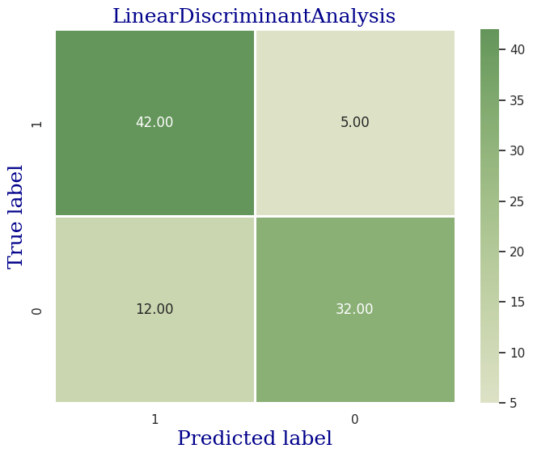

```python
evaluator.cfm()
```

```python
evaluator.accuracies(model=evaluator.getPipe())
```

```
acc_train: 83.49
acc_val: 79.12
```

```
Selected features:  {2: 'cp', 7: 'thalach', 9: 'oldpeak', 11: 'ca', 12: 'thal'}
```

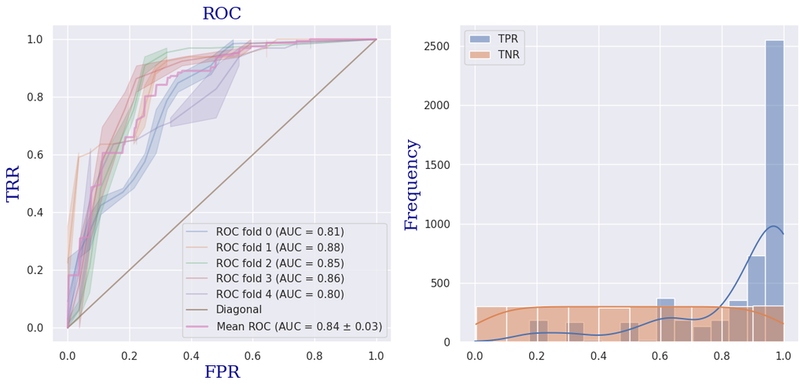

```python
evaluator.val_diags()
```

**Decision Trees:**  
Decision tree is a popular and interpretable machine learning algorithm used for both classification and regression tasks. It recursively splits the data based on the features, creating a tree-like structure where each internal node represents a decision based on a feature, and each leaf node represents a class label or regression output.

```python
evaluator = ModelEvaluator(model=tree.DecisionTreeClassifier())

evaluator.accuracies()
```

```
acc_train: 100.00
acc_val: 72.53
```

```python
evaluator.class_report()
```

|  | precision | recall | f1-score | support |
| --- | --- | --- | --- | --- |
| 0 | 0.852941 | 0.659091 | 0.743590 | 44.00000 |
| 1 | 0.736842 | 0.893617 | 0.807692 | 47.00000 |
| accuracy | 0.780220 | 0.780220 | 0.780220 | 0.78022 |
| macro avg | 0.794892 | 0.776354 | 0.775641 | 91.00000 |
| weighted avg | 0.792978 | 0.780220 | 0.776698 | 91.00000 |

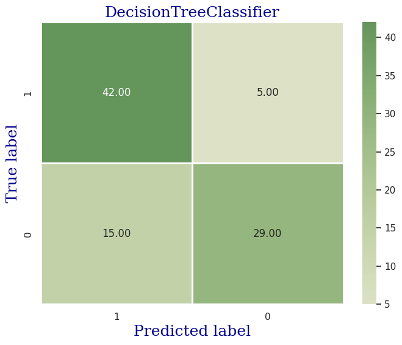

```python
evaluator.cfm()
```

```python
evaluator.accuracies(model=evaluator.getPipe())
```

```
acc_train: 88.68
acc_val: 74.73
```

```
Selected features:  {8: 'exang', 11: 'ca', 12: 'thal'}
```

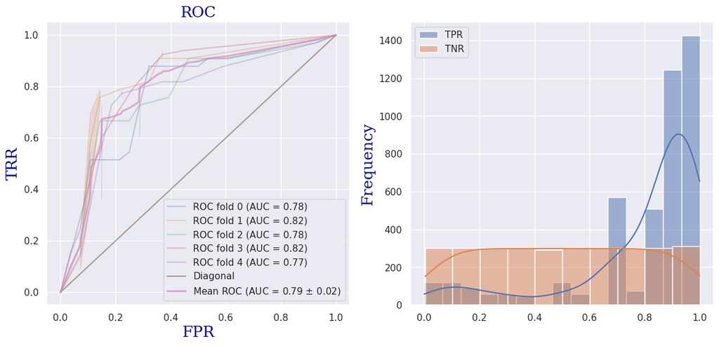

```python
evaluator.val_diags()
```

**Random Forests:**  
It is a popular machine learning algorithm used for classification tasks. It is an ensemble learning method that builds multiple decision trees during training and combines their predictions to make the final classification decision.

- n_estimators: The number of decision trees to be built in the random forest. Increasing the number of estimators generally improves the model's performance, but it also increases training time and memory requirements.
- random_state: The seed used by the random number generator. It is used to ensure reproducibility of results. Setting random_state=0 in the RandomForestClassifier means that the random number generator's seed is fixed to the value 0. This will ensure that the random initialization of the algorithm is the same every time you run the code, leading to consistent results. It effectively removes the randomness in the process, making the results reproducible.

```python
evaluator = ModelEvaluator( model=RandomForestClassifier(n_estimators=50, random_state = 0))
evaluator.accuracies()
```

```
acc_train: 100.00
acc_val: 84.62
```

```python
evaluator.class_report()
```

|  | precision | recall | f1-score | support |
| --- | --- | --- | --- | --- |
| 0 | 0.875000 | 0.795455 | 0.833333 | 44.000000 |
| 1 | 0.823529 | 0.893617 | 0.857143 | 47.000000 |
| accuracy | 0.846154 | 0.846154 | 0.846154 | 0.846154 |
| macro avg | 0.849265 | 0.844536 | 0.845238 | 91.000000 |
| weighted avg | 0.848416 | 0.846154 | 0.845631 | 91.000000 |

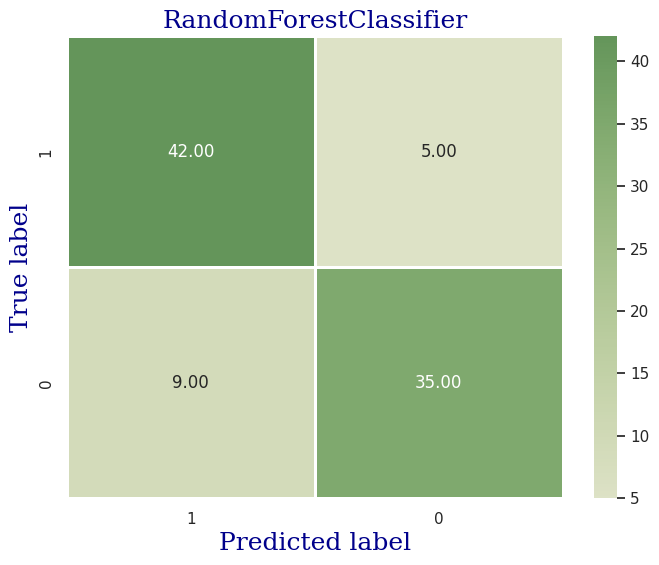

```python
evaluator.cfm()
```

```python
evaluator.accuracies(model=evaluator.getPipe())
```

```
acc_train: 93.40
acc_val: 68.13
```

```
Selected features:  {2: 'cp', 11: 'ca', 12: 'thal'}
```

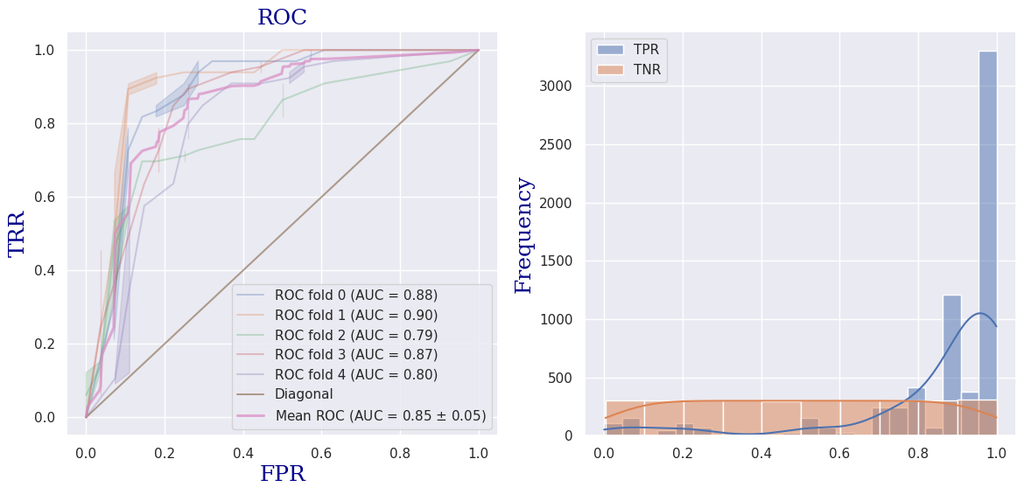

```python
evaluator.val_diags()
```

**Support Vector Classification (SVC):**  
SVC specifically refers to the implementation of Support Vector Machines (SVM) for classification tasks. It is used when dealing with labeled data and aims to find the best hyperplane that maximizes the margin between classes.

- kernel: This parameter specifies the type of function used to transform the input features into a higher-dimensional space, where the classes can be better separated. In this case, 'linear' indicates that a linear kernel is being used, which means the model is assuming that the data can be separated by a straight line in the feature space.
- probability: It indicates whether the SVC model should provide probability estimates for its predictions. When set to True, the model will calculate the probability scores of each class prediction. This can be helpful for tasks like ROC-AUC evaluation or when you want to assess the model's confidence in its predictions.

```python
evaluator = ModelEvaluator(model=SVC(kernel='linear',probability=True))
evaluator.accuracies()
```

```
acc_train: 86.79
acc_val: 80.22
```

```python
evaluator.class_report()
```

|  | precision | recall | f1-score | support |
| --- | --- | --- | --- | --- |
| 0 | 0.794872 | 0.704545 | 0.746988 | 44.000000 |
| 1 | 0.750000 | 0.829787 | 0.787879 | 47.000000 |
| accuracy | 0.769231 | 0.769231 | 0.769231 | 0.769231 |
| macro avg | 0.772436 | 0.767166 | 0.767433 | 91.000000 |
| weighted avg | 0.771696 | 0.769231 | 0.768107 | 91.000000 |

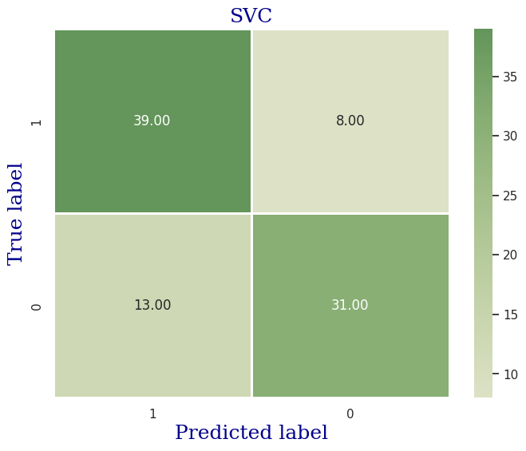

```python
evaluator.cfm()
```

```python
evaluator.accuracies(model=evaluator.getPipe())
```

```
acc_train: 84.43
acc_val: 79.12
```

```
Selected features:  {2: 'cp', 7: 'thalach', 8: 'exang', 11: 'ca'}
```

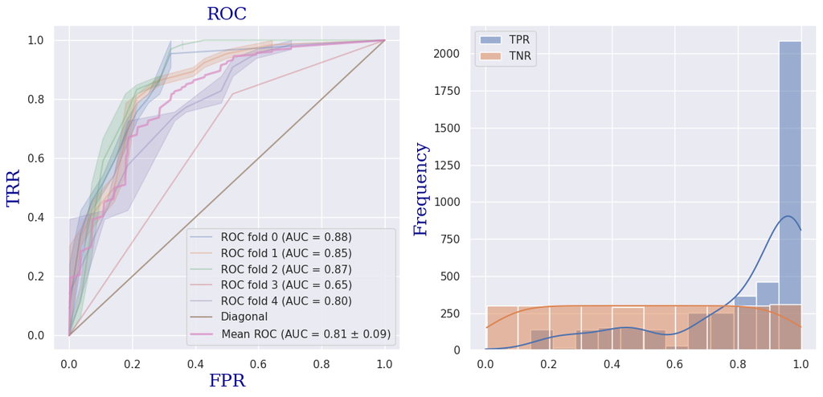

```python
evaluator.val_diags()
```

**Logistic Regression:**  
It is a classification algorithm used for binary and multiclass classification tasks. The logistic regression model is a linear classifier that models the probability of a sample belonging to a particular class using the [logistic (sigmoid)](https://en.wikipedia.org/wiki/Sigmoid_function) function.

```python
evaluator = ModelEvaluator(model= LogisticRegression(max_iter=1000))
evaluator.accuracies()
```

```
acc_train: 86.32
acc_val: 81.32
```

```python
evaluator.class_report()
```

|  | precision | recall | f1-score | support |
| --- | --- | --- | --- | --- |
| 0 | 0.837838 | 0.704545 | 0.765432 | 44.000000 |
| 1 | 0.759259 | 0.872340 | 0.811881 | 47.000000 |
| accuracy | 0.791209 | 0.791209 | 0.791209 | 0.791209 |
| macro avg | 0.798549 | 0.788443 | 0.788657 | 91.000000 |
| weighted avg | 0.797253 | 0.791209 | 0.789422 | 91.000000 |

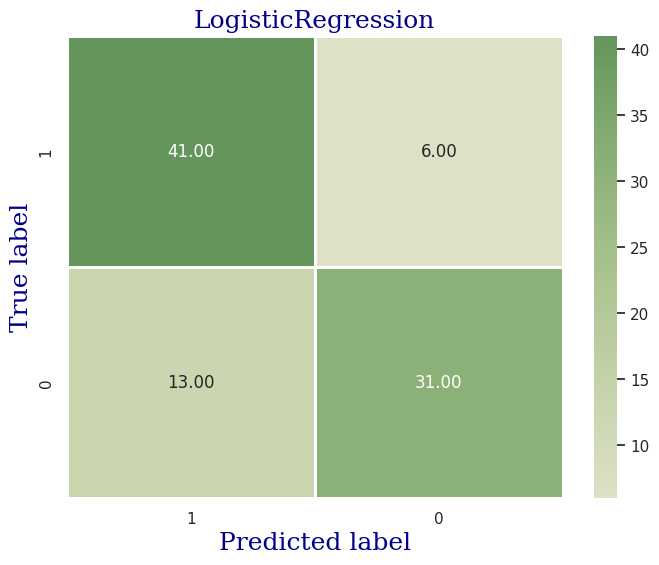

```python
evaluator.cfm()
```

```python
evaluator.accuracies(model=evaluator.getPipe())
```

```
acc_train: 81.60
acc_val: 81.32
```

```
Selected features:  {1: 'sex', 2: 'cp', 8: 'exang', 9: 'oldpeak', 11: 'ca'}
```

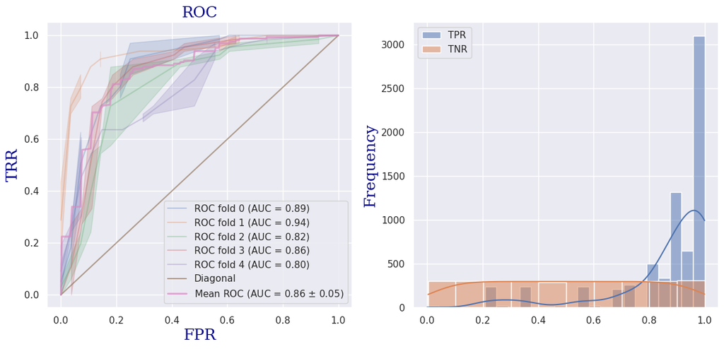

```python
evaluator.val_diags()
```

**Gradient Boosting:**  
Gradient Boosting is a powerful machine learning technique used for both regression and classification tasks. It belongs to the family of ensemble learning methods, which combine the predictions of multiple weak learners (usually decision trees) to create a strong predictive model.

- loss: This parameter defines the loss function to be optimized during the boosting process. The 'exponential' loss is suitable for classification problems and encourages the model to focus more on misclassified samples.
- learning_rate: The learning rate controls the contribution of each weak learner (individual decision tree) to the ensemble. A lower learning rate requires more iterations to reach optimal performance but can help prevent over-fitting.
- n_estimators: This is the number of weak learners (decision trees) that will be trained sequentially. Increasing the number of estimators can improve the model's performance, but it also increases computation time.
- max_depth: This parameter sets the maximum depth of the individual decision trees. It controls the complexity of the trees. A deeper tree can capture more complex relationships in the data but can also lead to over-fitting.

```python
evaluator = ModelEvaluator(model= GradientBoostingClassifier(loss='exponential', learning_rate=0.05, n_estimators=200, max_depth=6))
evaluator.accuracies()
```

```
acc_train: 100.00
acc_val: 80.22
```

```python
evaluator.class_report()
```

|  | precision | recall | f1-score | support |
| --- | --- | --- | --- | --- |
| 0 | 0.852941 | 0.659091 | 0.743590 | 44.00000 |
| 1 | 0.736842 | 0.893617 | 0.807692 | 47.00000 |
| accuracy | 0.780220 | 0.780220 | 0.780220 | 0.78022 |
| macro avg | 0.794892 | 0.776354 | 0.775641 | 91.00000 |
| weighted avg | 0.792978 | 0.780220 | 0.776698 | 91.00000 |

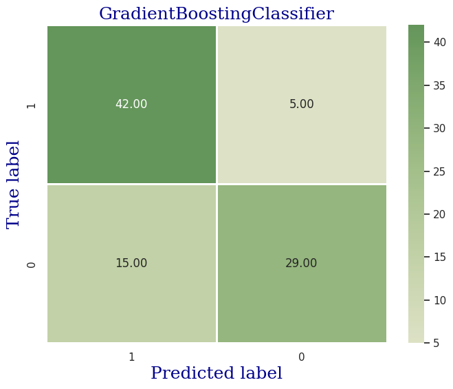

```python
evaluator.cfm()
```

```python
evaluator.accuracies(model=evaluator.getPipe())
```

```
acc_train: 88.68
acc_val: 74.73
```

```
Selected features:  {8: 'exang', 11: 'ca', 12: 'thal'}
```

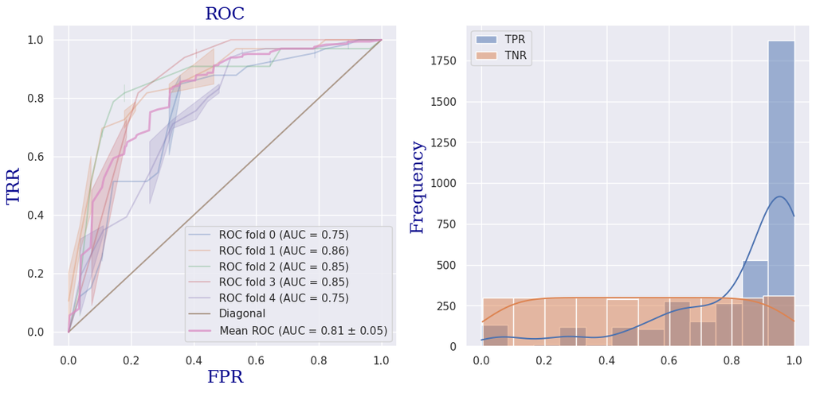

```python
evaluator.val_diags()
```

**K-Nearest Neighbors (KNN):**  
This is a class from [scikit-learn's neighbors](https://scikit-learn.org/stable/whats_new/v0.20.html#id36) module that represents the K-Nearest Neighbors classifier. KNN is a simple and effective classification algorithm used for both binary and multi-class classification tasks.

- n_neighbors: This is a parameter of the KNeighborsClassifier constructor. It specifies the number of neighbors to consider when making predictions. Each data point is classified by a majority vote of its n_neighbors nearest neighbors. The optimal number of neighbors is returned as the output of the function k_opt().

```python
evaluator = ModelEvaluator(model=KNeighborsClassifier(n_neighbors=evaluator.k_opt()))

evaluator.accuracies()
```

```
The optimal number of neighbors is 31 with avg_acc of KNN 83.6%.
acc_train: 84.91
acc_val: 78.02
```

```python
evaluator.class_report()
```

|  | precision | recall | f1-score | support |
| --- | --- | --- | --- | --- |
| 0 | 0.888889 | 0.727273 | 0.800000 | 44.000000 |
| 1 | 0.781818 | 0.914894 | 0.843137 | 47.000000 |
| accuracy | 0.824176 | 0.824176 | 0.824176 | 0.824176 |
| macro avg | 0.835354 | 0.821083 | 0.821569 | 91.000000 |
| weighted avg | 0.833589 | 0.824176 | 0.822280 | 91.000000 |

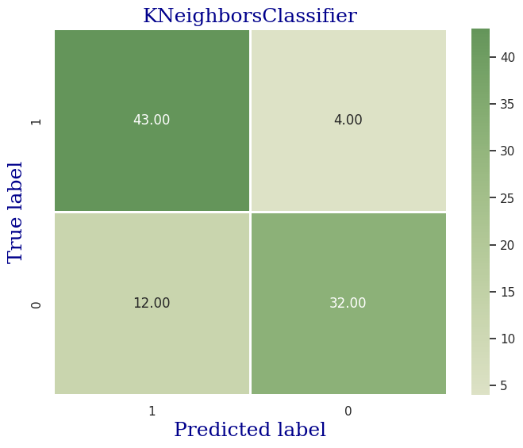

```python
evaluator.cfm()
```

```python
evaluator.accuracies(model=evaluator.getPipe())
```

```
acc_train: 83.96
acc_val: 80.22
```

```
Selected features:  {2: 'cp', 7: 'thalach', 11: 'ca', 12: 'thal'}
```

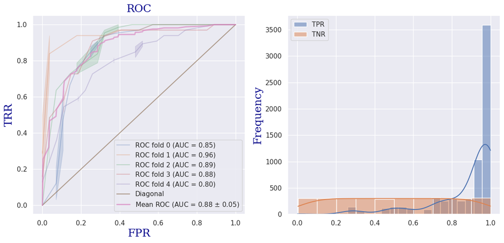

```python
evaluator.val_diags()
```

**Neural Networks:**  
Neural networks are advanced machine learning models widely used for classification tasks. They are inspired by the human brain's interconnected neurons and are highly effective in solving complex classification problems. In this context, they learn to map input data to different classes, making them invaluable tools for tasks like image recognition, sentiment analysis, disease diagnosis, and more. Neural networks' ability to automatically learn intricate patterns and hierarchies in data makes them a go-to choice when dealing with complex and non-linear classification challenges. To create an effective neural network, consider the following input parameters that influence the model's performance and convergence:

- Number of Hidden Units: The capacity of a model to learn intricate patterns depends on the number of hidden units in each layer (they are here set to hu1= 64 and hu2=32 as default). More hidden units can capture complex relationships, but they also risk [over-fitting](https://www.kaggle.com/code/ryanholbrook/overfitting-and-underfitting) if not properly regularized. Experimentation helps find the ideal balance of hidden units for your specific problem.
- Number of Epochs: The epochs determine how many times the model processes the training dataset(it is here set to 1000 as default). Too few epochs may cause under-fitting, while excessive epochs may lead to over-fitting. Monitoring validation performance and stopping training at the right moment can help find the optimal balance.
- Learning Rate: The learning rate controls the step size during parameter updates in training (It is here set to 0.001 as default). A higher rate speeds up convergence but might lead to overshooting. Conversely, a smaller rate may result in slow convergence. Adaptive optimizers like Adam can alleviate manual tuning of the learning rate.

These parameters collectively shape the neural network's architecture and training dynamics, guiding it towards effectively learning from data and achieving the desired classification performance.

```python
evaluator = ModelEvaluator()
```

```
Accuracies of the network on test data: 83.52%
Accuracies of the network on training data: 97.64%
```

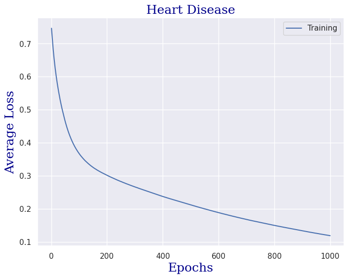

```python
#nnw(self, hu1=64, hu2=32, lr=0.001, num_epoch=1000, _tqdm=True)
evaluator.nnw()
```

```
Accuracies of the network on test data: 84.62%
Accuracies of the network on training data: 96.70%
```

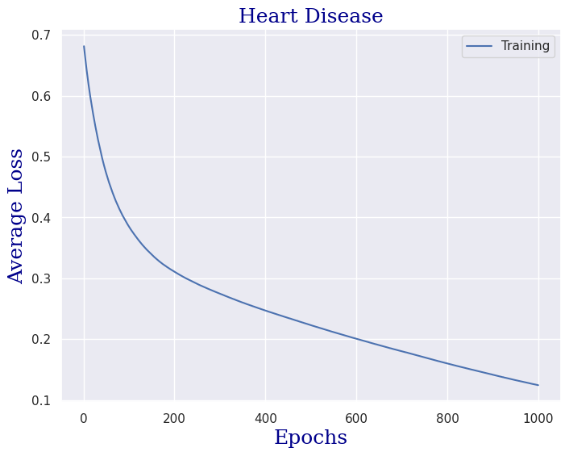

```python
evaluator.nnw(_tqdm=False)
```

### Comparison Models

After training, testing, and obtaining the respective accuracies for the selected models, our next step involves comparing all the developed models. This comparison is crucial for evaluating the performance of each model and making well-informed decisions about which one is most suitable for our specific problem (in our case heat disease prediction). By carefully analyzing the achieved accuracies across different models, as highlighted in the previous section, we can pinpoint the model that demonstrates the highest classification performance. This informed decision-making process enables us to select the optimal model for deployment or consider further optimization if needed.  
This section offers a succinct overview of the accuracy scores achieved by various machine learning algorithms in the last section on the heart disease prediction. The focus here is primarily on the accuracy metrics for both the test and training datasets. The presented table showcases a sorted list of algorithms along with their corresponding test values.

```python
results = evaluator.results
df_comparsion = pd.DataFrame.from_dict(results,
orient='index' ).transpose().sort_values('acc_test',ascending= True)
# Sorted  by Test Accuracy
df_comparsion
```

|  | acc_test | acc_train |
| --- | --- | --- |
| RandomForestClassifier_pip | 68.13 | 93.40 |
| DecisionTreeClassifier | 72.53 | 100.00 |
| DecisionTreeClassifier_pip | 74.73 | 88.68 |
| GradientBoostingClassifier_pip | 74.73 | 88.68 |
| KNeighborsClassifier | 78.02 | 84.91 |
| LinearDiscriminantAnalysis_pip | 79.12 | 83.49 |
| SVC_pip | 79.12 | 84.43 |
| LinearDiscriminantAnalysis | 80.22 | 85.38 |
| SVC | 80.22 | 86.79 |
| GradientBoostingClassifier | 80.22 | 100.00 |
| KNeighborsClassifier_pip | 80.22 | 83.96 |
| LogisticRegression | 81.32 | 86.32 |
| LogisticRegression_pip | 81.32 | 81.60 |
| RandomForestClassifier | 84.62 | 100.00 |

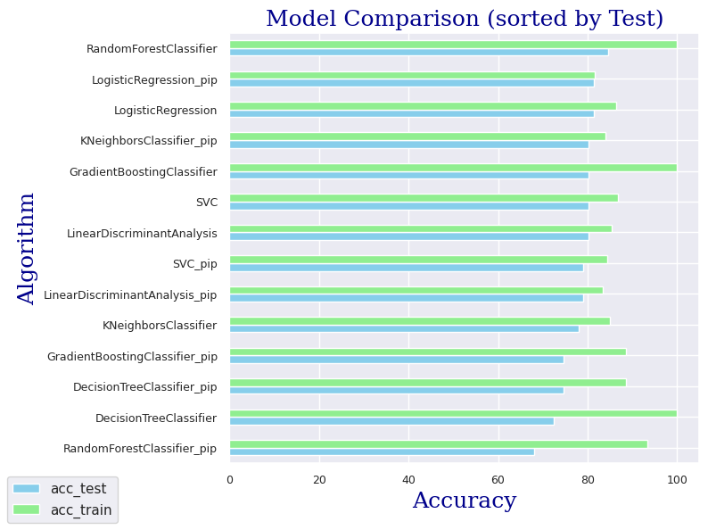

```python
fg11 = df_comparsion.plot(kind='barh', color=['skyblue', 'lightgreen'], fontsize=9, legend=False)
plt.figlegend( ncol=1, frameon=True,loc= 'lower left')
#plt.figure(dpi=1000)

fg11.set_xlabel('Accuracy', fontdict=font)
fg11.set_ylabel('Algorithm', fontdict=font)
fg11.set_title('Model Comparison (sorted by Test)',  fontdict=font)
plt.tight_layout()
```

# Conclusion

In this analysis, we embarked on a comprehensive journey through the development and evaluation of data-driven classification models for the task of heart disease prediction. Starting with the selection of relevant features and the construction of a well-balanced training and testing dataset, we delved into the heart of model selection and evaluation.

The Data-driven Model section illuminated the significance of data-driven approaches in solving classification problems. By partitioning computational methods into classification categories, we zoomed in on classification—a process aimed at predicting class labels for new data based on its features. Feature Selection emerged as a pivotal step, involving the identification of crucial features that drive accurate predictions. Our use of the Sequential Feature Selector (SFS) with a customized configuration allowed us to hone in on informative features while mitigating dimensionality issues.

The Train-Test Split step was a foundational preparation, splitting the dataset into training and testing subsets to enable robust model evaluation.

The heart of the analysis, Model Selection and Evaluation, showcased our commitment to informed decision-making. Leveraging the ModelEvaluator class, we systematically assessed multiple classification algorithms based on essential metrics like precision, recall, F1-score, support, and accuracies. This approach not only ensured a rigorous comparison but also facilitated visualization of ROC curves and confusion matrices. The utilization of an objective-oriented programming (OOP) paradigm enhanced the modularity and reusability of our code, underpinning a streamlined and comprehensive evaluation process.

In the Comparison Models section, we distilled the essence of our efforts into a concise yet revealing table of accuracy scores. This table illuminated the performance of various algorithms on both the test and training datasets, providing valuable insights into their generalization capabilities and potential overfitting tendencies.

As we conclude, it's imperative to acknowledge that while accuracy is an essential metric, the evaluation process should be multifaceted. The decision on the best model should be informed by precision, recall, F1-score, domain knowledge, and other contextual considerations.

Ultimately, this analysis serves as a strong foundation for the deployment of an effective classification model for heart disease prediction. It underscores the iterative and exploratory nature of machine learning, encouraging ongoing optimization, fine-tuning, and model enhancement. Armed with this knowledge, we're equipped to make informed decisions in real-world scenarios, contributing to the advancement of healthcare and data-driven solutions.

**Back to Table of Contents**